# Recommender Systems

In this lesson we’ll:

1. Introduce recommender systems based on collaborative filtering
2. Build recommender systems based on various kinds of collaborative filtering
   - user-based collaborative filtering
   - item-based collaborative filtering
   - matrix factorization
3. Introduce L2 regularization and bias terms, two ways of improving recommender systems based on matrix factorization.
4. Use these approaches to build a system for recommending movies to users based on their past viewing habits.

This notebook is based on the following sources:

- Chapter 22 of Joel Grus’ [“Data Science from Scratch: First Principles with Python”](http://shop.oreilly.com/product/0636920033400.do). The (Python) code from the book is [here](https://github.com/joelgrus/data-science-from-scratch).
- Part of [Lesson 6](https://course.fast.ai/videos/?lesson=6) of the fast.ai course “Practical Deep Learning for Coders”. Code (also in Python) is [here](https://github.com/fastai/courses/tree/master/deeplearning1).

### Load required packages and the dataset we created in a previous lesson

```r
library(dplyr)
library(tidyr)
library(stringr)
library(ggplot2)
library(DT)
library(keras3)
reticulate::use_condaenv("r-tensorflow", required = TRUE)

load("data/recommender.RData")
datatable(
  viewed_movies,
  rownames = FALSE,
  options = list(dom = "tip", pageLength = 5)
)
```

| userId | 2001: A Space Odyssey (1968) | Apocalypse Now (1979) | Big Lebowski, The (1998) | Bourne Identity, The (2002) | Clear and Present Danger (1994) | Crouching Tiger, Hidden Dragon (Wo hu cang long) (2000) | Departed, The (2006) | Donnie Darko (2001) | Ferris Bueller's Day Off (1986) | Green Mile, The (1999) | Harry Potter and the Sorcerer's Stone (a.k.a. Harry Potter and the Philosopher's Stone) (2001) | Indiana Jones and the Temple of Doom (1984) | Interview with the Vampire: The Vampire Chronicles (1994) | Jumanji (1995) | Kill Bill: Vol. 2 (2004) | Shining, The (1980) | Sleepless in Seattle (1993) | Star Trek: Generations (1994) | There's Something About Mary (1998) | Up (2009) |
| --- | --- | --- | --- | --- | --- | --- | --- | --- | --- | --- | --- | --- | --- | --- | --- | --- | --- | --- | --- | --- |
| 1 | 0 | 1 | 1 | 0 | 1 | 0 | 0 | 0 | 0 | 1 | 0 | 1 | 0 | 0 | 0 | 1 | 0 | 0 | 0 | 0 |
| 20 | 0 | 0 | 0 | 1 | 0 | 1 | 0 | 0 | 0 | 0 | 1 | 0 | 0 | 1 | 0 | 0 | 0 | 0 | 0 | 0 |
| 187 | 1 | 0 | 1 | 0 | 0 | 1 | 0 | 1 | 0 | 0 | 0 | 0 | 1 | 0 | 1 | 1 | 0 | 0 | 0 | 0 |
| 198 | 1 | 0 | 1 | 0 | 0 | 1 | 0 | 0 | 0 | 1 | 0 | 1 | 0 | 0 | 0 | 1 | 0 | 0 | 0 | 0 |
| 212 | 1 | 0 | 1 | 0 | 0 | 0 | 0 | 0 | 1 | 0 | 1 | 0 | 0 | 0 | 0 | 1 | 0 | 0 | 0 | 1 |
| 222 | 0 | 1 | 1 | 0 | 0 | 0 | 1 | 0 | 0 | 0 | 0 | 0 | 0 | 1 | 1 | 0 | 0 | 0 | 1 | 1 |
| 282 | 0 | 1 | 1 | 1 | 0 | 0 | 1 | 0 | 1 | 1 | 0 | 1 | 0 | 0 | 1 | 1 | 0 | 0 | 0 | 0 |
| 328 | 1 | 1 | 1 | 1 | 0 | 0 | 1 | 1 | 1 | 0 | 1 | 1 | 0 | 0 | 1 | 1 | 0 | 0 | 0 | 1 |
| 330 | 1 | 1 | 1 | 1 | 0 | 1 | 1 | 1 | 1 | 1 | 1 | 0 | 1 | 1 | 1 | 1 | 1 | 0 | 1 | 0 |
| 372 | 1 | 1 | 0 | 0 | 0 | 0 | 0 | 0 | 0 | 0 | 0 | 0 | 0 | 0 | 0 | 1 | 0 | 0 | 0 | 0 |

[output cut: 5 more lines]

For the sake of neater display throughout, let’s shorten the Harry Potter movie title.

```r
viewed_movies <- rename(viewed_movies,
  `Harry Potter and the Philosopher's Stone (2001)` = `Harry Potter and the Sorcerer's Stone (a.k.a. Harry Potter and the Philosopher's Stone) (2001)`
)
```

We first need to convert the data to matrix form otherwise some of the later functions we use will give an error (see what happens if you don’t make the change).

```r
sorted_my_users <- as.character(unlist(viewed_movies[, 1]))
viewed_movies <- as.matrix(viewed_movies[, -1])
row.names(viewed_movies) <- sorted_my_users
```

## User-based collaborative filtering

### The basic idea behind user-based collaborative filtering

A really simple recommender system would just recommend the most popular movies (that a user hasn’t seen before). This information is obtained by summing the values of each column of *viewed movies*:

```r
apply(viewed_movies, 2, sum) |>
  sort(decreasing = TRUE) |>
  data.frame()
```

```
                                                          sort.apply.viewed_movies..2..sum...decreasing...TRUE.
Shining, The (1980)                                                                                          11
Big Lebowski, The (1998)                                                                                     10
Apocalypse Now (1979)                                                                                         9
Kill Bill: Vol. 2 (2004)                                                                                      8
2001: A Space Odyssey (1968)                                                                                  7
Departed, The (2006)                                                                                          7
Ferris Bueller's Day Off (1986)                                                                               7
Green Mile, The (1999)                                                                                        7
Bourne Identity, The (2002)                                                                                   6
Jumanji (1995)                                                                                                6
Crouching Tiger, Hidden Dragon (Wo hu cang long) (2000)                                                       5
Harry Potter and the Philosopher's Stone (2001)                                                               5
Indiana Jones and the Temple of Doom (1984)                                                                   5
Up (2009)                                                                                                     5
Donnie Darko (2001)                                                                                           4
Interview with the Vampire: The Vampire Chronicles (1994)                                                     4
There's Something About Mary (1998)                                                                           4
Sleepless in Seattle (1993)                                                                                   3
Clear and Present Danger (1994)                                                                               2
Star Trek: Generations (1994)                                                                                 1
```

This approach has an intuitive appeal but is pretty unsophisticated (everyone gets the same recommendations, barring the filtering out of seen movies!) In other words, everyone’s vote counts the same.

User-based CF extends the approach by changing how much each person’s vote counts. Specifically, when recommending what I should watch next, a user-based CF system will upweight the votes of people that are “more similar” to me. In this context “similar” means “has seen many of the same movies as me”. You can think of this as replacing the 1’s in the *viewed_movies* matrix with a number that increases with similarity to the user we’re trying to recommend a movie to.

There are lots of different similarity measures. The one we’ll use is called cosine similarity and is widely used, but search online for others and try them out.

Cosine similarity derives its name from the fact that it measures the cosine of the angle between two non-zero vectors. The closer the vectors lie to each other, the smaller the angle, and the closer the cosine is to 1. It can be shown that for two vectors $\boldsymbol x$ and $\boldsymbol y$:

$$cos(\theta) = \frac{\boldsymbol x \cdot \boldsymbol y}{||\boldsymbol x|| \ ||\boldsymbol y||} = \frac{\sum_{i=1}^{n}x_iy_i}{\sqrt{\sum_{i=1}^{n}x^2_i} \sqrt{\sum_{i=1}^{n}y^2_i}}$$
We can use the `crossprod()` function in R to calculate the dot products.

```r
# function calculating cosine similarity
cosine_sim <- function(a, b) {
  crossprod(a, b) / sqrt(crossprod(a) * crossprod(b))
}
```

Cosine similarity lies between 0 and 1 inclusive and increases with similarity. Here are a few test cases to get a feel for it:

```r
# maximally similar
x1 <- c(1, 1, 1, 0, 0)
x2 <- c(1, 1, 1, 0, 0)
cosine_sim(x1, x2)
```

```
     [,1]
[1,]    1
```

```r
# maximally dissimilar
x1 <- c(1, 1, 1, 0, 0)
x2 <- c(0, 0, 0, 1, 1)
cosine_sim(x1, x2)
```

```
     [,1]
[1,]    0
```

```r
# but also
x1 <- c(1, 1, 0, 0, 0)
x2 <- c(0, 0, 0, 1, 1)
cosine_sim(x1, x2)
```

```
     [,1]
[1,]    0
```

```r
# try an example from our data
as.numeric(viewed_movies[1, ]) # user 1's viewing history
```

```
 [1] 0 1 1 0 1 0 0 0 0 1 0 1 0 0 0 1 0 0 0 0
```

```r
as.numeric(viewed_movies[3, ]) # user 3's viewing history
```

```
 [1] 1 0 1 0 0 1 0 1 0 0 0 0 1 0 1 1 0 0 0 0
```

```r
cosine_sim(viewed_movies[1, ], viewed_movies[3, ])
```

```
          [,1]
[1,] 0.3086067
```

Let’s get similarities between user pairs. We’ll do this with a loop below, because it’s easier to see what’s going on, but this will be inefficient and very slow for bigger datasets.

> As an exercise, see if you can do the same without loops.

```r
user_similarities <- matrix(0, nrow = 15, ncol = 15)
for (i in 1:14) {
  for (j in (i + 1):15) {
    user_similarities[i, j] <- cosine_sim(viewed_movies[i, ], viewed_movies[j, ])
  }
}
user_similarities <- user_similarities + t(user_similarities)
# diag(user_similarities) <- 0
row.names(user_similarities) <- row.names(viewed_movies)
colnames(user_similarities) <- row.names(viewed_movies)
round(user_similarities, 2)
```

```
       1   20  187  198  212  222  282  328  330  372  432  434  495  562  594
1   0.00 0.00 0.31 0.67 0.33 0.31 0.68 0.47 0.41 0.47 0.29 0.59 0.37 0.41 0.17
20  0.00 0.00 0.19 0.20 0.20 0.19 0.17 0.29 0.50 0.00 0.35 0.49 0.00 0.00 0.20
187 0.31 0.19 0.00 0.62 0.46 0.29 0.38 0.55 0.66 0.44 0.40 0.55 0.34 0.19 0.15
198 0.67 0.20 0.62 0.00 0.50 0.15 0.54 0.47 0.51 0.47 0.29 0.59 0.18 0.41 0.00
212 0.33 0.20 0.46 0.50 0.00 0.31 0.41 0.71 0.51 0.47 0.29 0.59 0.37 0.41 0.00
222 0.31 0.19 0.29 0.15 0.31 0.00 0.50 0.55 0.57 0.22 0.53 0.64 0.68 0.00 0.46
282 0.68 0.17 0.38 0.54 0.41 0.50 0.00 0.77 0.67 0.38 0.59 0.73 0.75 0.50 0.14
328 0.47 0.29 0.55 0.47 0.71 0.55 0.77 0.00 0.72 0.50 0.51 0.84 0.65 0.29 0.12
330 0.41 0.50 0.66 0.51 0.51 0.57 0.67 0.72 0.00 0.43 0.62 0.85 0.56 0.50 0.51
372 0.47 0.00 0.44 0.47 0.47 0.22 0.38 0.50 0.43 0.00 0.20 0.42 0.26 0.29 0.24
432 0.29 0.35 0.40 0.29 0.29 0.53 0.59 0.51 0.62 0.20 0.00 0.60 0.32 0.35 0.29
434 0.59 0.49 0.55 0.59 0.59 0.64 0.73 0.84 0.85 0.42 0.60 0.00 0.54 0.36 0.30
495 0.37 0.00 0.34 0.18 0.37 0.68 0.75 0.65 0.56 0.26 0.32 0.54 0.00 0.22 0.18
562 0.41 0.00 0.19 0.41 0.41 0.00 0.50 0.29 0.50 0.29 0.35 0.36 0.22 0.00 0.20
594 0.17 0.20 0.15 0.00 0.00 0.46 0.14 0.12 0.51 0.24 0.29 0.30 0.18 0.20 0.00
```

```r
# who are the most similar users to user 222?
user_similarities["222", ] |> sort() |> round(2)
```

```
 222  562  198   20  372  187    1  212  594  282  432  328  330  434  495
0.00 0.00 0.15 0.19 0.22 0.29 0.31 0.31 0.46 0.50 0.53 0.55 0.57 0.64 0.68
```

Let’s see if this makes sense from the viewing histories. Below we show user 222’s history, together with the user who is most similar to user 222 (user 495) and another user who is very dissimilar (user 562).

```r
t(viewed_movies[c("222", "495", "562"), ])
```

```
                                                          222 495 562
2001: A Space Odyssey (1968)                                0   0   0
Apocalypse Now (1979)                                       1   1   0
Big Lebowski, The (1998)                                    1   1   0
Bourne Identity, The (2002)                                 0   0   0
Clear and Present Danger (1994)                             0   0   0
Crouching Tiger, Hidden Dragon (Wo hu cang long) (2000)     0   0   0
Departed, The (2006)                                        1   1   0
Donnie Darko (2001)                                         0   0   0
Ferris Bueller's Day Off (1986)                             0   1   1
Green Mile, The (1999)                                      0   0   1
Harry Potter and the Philosopher's Stone (2001)             0   0   0
Indiana Jones and the Temple of Doom (1984)                 0   0   0
Interview with the Vampire: The Vampire Chronicles (1994)   0   0   0
Jumanji (1995)                                              1   0   0
Kill Bill: Vol. 2 (2004)                                    1   1   0
Shining, The (1980)                                         0   0   1
Sleepless in Seattle (1993)                                 0   0   1
Star Trek: Generations (1994)                               0   0   0
There's Something About Mary (1998)                         1   0   0
Up (2009)                                                   1   0   0
```

### Recommending movies for a single user

As an example, let’s consider the process of recommending a movie to one user, say user 222. How would we do this with a user-based collaborative filtering system?

First, we need to know what movies have they already seen (so we don’t recommend these).

```r
data.frame(seen = viewed_movies["222", ])
```

```
                                                          seen
2001: A Space Odyssey (1968)                                 0
Apocalypse Now (1979)                                        1
Big Lebowski, The (1998)                                     1
Bourne Identity, The (2002)                                  0
Clear and Present Danger (1994)                              0
Crouching Tiger, Hidden Dragon (Wo hu cang long) (2000)      0
Departed, The (2006)                                         1
Donnie Darko (2001)                                          0
Ferris Bueller's Day Off (1986)                              0
Green Mile, The (1999)                                       0
Harry Potter and the Philosopher's Stone (2001)              0
Indiana Jones and the Temple of Doom (1984)                  0
Interview with the Vampire: The Vampire Chronicles (1994)    0
Jumanji (1995)                                               1
Kill Bill: Vol. 2 (2004)                                     1
Shining, The (1980)                                          0
Sleepless in Seattle (1993)                                  0
Star Trek: Generations (1994)                                0
There's Something About Mary (1998)                          1
Up (2009)                                                    1
```

The basic idea is now to recommend what’s popular by adding up the number of users that have seen each movie, but *to weight each user by their similarity to user 222*.

Let’s work through the calculations for one movie, say 2001: A Space Odyssey (movie 1). The table below shows who’s seen 2001: A Space Odyssey, and how similar each person is to user 222.

```r
seen_movie <- viewed_movies[, "2001: A Space Odyssey (1968)"]
sim_to_user <- user_similarities["222", ]
data.frame(seen_movie, sim_to_user, score = seen_movie * sim_to_user)
```

```
    seen_movie sim_to_user     score
1            0   0.3086067 0.0000000
20           0   0.1889822 0.0000000
187          1   0.2857143 0.2857143
198          1   0.1543033 0.1543033
212          1   0.3086067 0.3086067
222          0   0.0000000 0.0000000
282          0   0.5039526 0.0000000
328          1   0.5455447 0.5455447
330          1   0.5669467 0.5669467
372          1   0.2182179 0.2182179
432          0   0.5345225 0.0000000
434          1   0.6416889 0.6416889
495          0   0.6761234 0.0000000
562          0   0.0000000 0.0000000
594          0   0.4629100 0.0000000
```

The basic idea in user-based collaborative filtering is that user 372’s vote counts less than user 434’s, because user 434 is more similar to user 222 (in terms of viewing history).

Note that this only means user 434 counts more in the context of making recommendations to user 222. When recommending to users *other than user 222*, user 372 may carry more weight.

We can now work out an overall recommendation score for 2001: A Space Odyssey by multiplying together the two elements in each row of the table above, and summing these products (taking the dot product):

```r
# overall score for 2001: A Space Odyssey
crossprod(viewed_movies[, "2001: A Space Odyssey (1968)"], user_similarities["222", ])
```

```
         [,1]
[1,] 2.721023
```

Let’s repeat this calculation for all movies and compare recommendation scores:

```r
crossprod(viewed_movies, user_similarities["222", ])
```

```
                                                               [,1]
2001: A Space Odyssey (1968)                              2.7210226
Apocalypse Now (1979)                                     3.9239911
Big Lebowski, The (1998)                                  3.9914875
Bourne Identity, The (2002)                               2.9816377
Clear and Present Danger (1994)                           0.9502956
Crouching Tiger, Hidden Dragon (Wo hu cang long) (2000)   1.8376355
Departed, The (2006)                                      3.4687789
Donnie Darko (2001)                                       2.0398947
Ferris Bueller's Day Off (1986)                           3.2428631
Green Mile, The (1999)                                    2.7100208
Harry Potter and the Philosopher's Stone (2001)           2.2517693
Indiana Jones and the Temple of Doom (1984)               2.1540964
Interview with the Vampire: The Vampire Chronicles (1994) 1.8500935
Jumanji (1995)                                            2.3950504
Kill Bill: Vol. 2 (2004)                                  3.7544932
Shining, The (1980)                                       4.0681044
Sleepless in Seattle (1993)                               1.0298568
Star Trek: Generations (1994)                             0.4629100
There's Something About Mary (1998)                       1.6715457
Up (2009)                                                 2.0303629
```

```r
# or equivalently
# t(viewed_movies) %*% user_similarities["222", ]
```

To come up with a final recommendation, we just need to remember to remove movies user 222 has already seen, and sort the remaining movies in descending order of recommendation score.

We do that below, after tidying up the results a bit by putting them in a data frame.

```r
user_scores <- data.frame(
  title = colnames(viewed_movies),
  score = as.vector(user_similarities["222", ] %*% viewed_movies),
  seen = as.vector(viewed_movies["222", ])
)
user_scores |>
  filter(seen == 0) |>
  arrange(desc(score))
```

```
                                                       title     score seen
1                                        Shining, The (1980) 4.0681044    0
2                            Ferris Bueller's Day Off (1986) 3.2428631    0
3                                Bourne Identity, The (2002) 2.9816377    0
4                               2001: A Space Odyssey (1968) 2.7210226    0
5                                     Green Mile, The (1999) 2.7100208    0
6            Harry Potter and the Philosopher's Stone (2001) 2.2517693    0
7                Indiana Jones and the Temple of Doom (1984) 2.1540964    0
8                                        Donnie Darko (2001) 2.0398947    0
9  Interview with the Vampire: The Vampire Chronicles (1994) 1.8500935    0
10   Crouching Tiger, Hidden Dragon (Wo hu cang long) (2000) 1.8376355    0
11                               Sleepless in Seattle (1993) 1.0298568    0
12                           Clear and Present Danger (1994) 0.9502956    0
13                             Star Trek: Generations (1994) 0.4629100    0
```

Therefore, our top recommendation for user 222 is “The Shining”.

Now that we’ve understood the calculations, let’s get recommendations for one more user, user 372:

```r
# recommendations for user 372
user_scores <- data.frame(
  title = colnames(viewed_movies),
  score = as.vector(user_similarities["372", ] %*% viewed_movies),
  seen = as.vector(viewed_movies["372", ])
)
user_scores |>
  filter(seen == 0) |>
  arrange(desc(score))
```

```
                                                       title     score seen
1                                   Big Lebowski, The (1998) 4.0650630    0
2                                   Kill Bill: Vol. 2 (2004) 2.8549736    0
3                            Ferris Bueller's Day Off (1986) 2.7562755    0
4                                     Green Mile, The (1999) 2.6736052    0
5                                       Departed, The (2006) 2.4185378    0
6                Indiana Jones and the Temple of Doom (1984) 2.2477932    0
7                                Bourne Identity, The (2002) 1.9421211    0
8            Harry Potter and the Philosopher's Stone (2001) 1.8245012    0
9                                                  Up (2009) 1.8138306    0
10                                       Donnie Darko (2001) 1.7895325    0
11   Crouching Tiger, Hidden Dragon (Wo hu cang long) (2000) 1.7609370    0
12                                            Jumanji (1995) 1.5111410    0
13 Interview with the Vampire: The Vampire Chronicles (1994) 1.3092749    0
14                       There's Something About Mary (1998) 1.3070169    0
15                               Sleepless in Seattle (1993) 0.9573901    0
16                           Clear and Present Danger (1994) 0.8914885    0
17                             Star Trek: Generations (1994) 0.2357023    0
```

We would recommend “The Big Lebowski” to user 372.

### A simple function to generate a user-based CF recommendation for any user

```r
# a function to generate a recommendation for any user
user_based_recommendations <- function(user, user_sim, viewed_mov) {
  # turn into character if not already
  user <- ifelse(is.character(user), user, as.character(user))

  # get scores
  user_scores <- data.frame(
    title = colnames(viewed_mov),
    score = as.vector(user_sim[user, ] %*% viewed_mov),
    seen = as.vector(viewed_mov[user, ])
  )

  # sort unseen movies by score and remove the 'seen' column
  user_scores |>
    filter(seen == 0) |>
    arrange(desc(score)) |>
    select(-seen)
}
```

Let’s check the function is working by running it on a user we’ve used before:

```r
user_based_recommendations(user = 222, user_sim = user_similarities, viewed_mov = viewed_movies)
```

```
                                                       title     score
1                                        Shining, The (1980) 4.0681044
2                            Ferris Bueller's Day Off (1986) 3.2428631
3                                Bourne Identity, The (2002) 2.9816377
4                               2001: A Space Odyssey (1968) 2.7210226
5                                     Green Mile, The (1999) 2.7100208
6            Harry Potter and the Philosopher's Stone (2001) 2.2517693
7                Indiana Jones and the Temple of Doom (1984) 2.1540964
8                                        Donnie Darko (2001) 2.0398947
9  Interview with the Vampire: The Vampire Chronicles (1994) 1.8500935
10   Crouching Tiger, Hidden Dragon (Wo hu cang long) (2000) 1.8376355
11                               Sleepless in Seattle (1993) 1.0298568
12                           Clear and Present Danger (1994) 0.9502956
13                             Star Trek: Generations (1994) 0.4629100
```

Now do it for all users with `lapply`:

```r
lapply(sorted_my_users, user_based_recommendations, user_similarities, viewed_movies)
```

```
[[1]]
                                                       title     score
1                                   Kill Bill: Vol. 2 (2004) 3.4251921
2                            Ferris Bueller's Day Off (1986) 3.2608851
3                               2001: A Space Odyssey (1968) 3.2537526
4                                       Departed, The (2006) 3.1165854
5                                Bourne Identity, The (2002) 2.4428303
6                                                  Up (2009) 1.9961082
7    Crouching Tiger, Hidden Dragon (Wo hu cang long) (2000) 1.9776102
8            Harry Potter and the Philosopher's Stone (2001) 1.8070747
9                                        Donnie Darko (2001) 1.7823480
10                                            Jumanji (1995) 1.7662853
11                       There's Something About Mary (1998) 1.4776102
12 Interview with the Vampire: The Vampire Chronicles (1994) 1.1721968
13                               Sleepless in Seattle (1993) 0.9831632
```

[output cut: 213 more lines]

> As an exercise, display all these recommendation scores in the $15 \times 20$ matrix relating users to movies, with blanks in the cells where a user has already watched a movie.

> A variant on the above is a *k-nearest-neighbours* approach that bases recommendations *only on k most similar users*. This is faster when there are many users. Try to implement this as an additional exercise.

## Item-based collaborative filtering

### The basic idea behind item-based collaborative filtering

Item-based collaborative filtering works very similarly to its user-based counterpart, although you might find it slightly less intuitive. It is also based on similarities, but similarities between *movies* rather than *users*.

There are two main conceptual parts to item-based collaborative filtering:

1. One movie is similar to another if many of the same users have seen both movies.
2. When deciding what movie to recommend to a particular user, movies are evaluated on how similar they are to movies *that the user has already seen*.

Let’s start by computing the similarities between all pairs of movies. We can reuse the same code we used to compute user similarities, if we first transpose the *viewed_movies* matrix.

```r
# transpose the viewed_movies matrix
movies_user <- t(viewed_movies)

# get all similarities between MOVIES
movie_similarities <- matrix(0, nrow = 20, ncol = 20)
for (i in 1:19) {
  for (j in (i + 1):20) {
    movie_similarities[i, j] <- cosine_sim(viewed_movies[, i], viewed_movies[, j])
  }
}
movie_similarities <- movie_similarities + t(movie_similarities)
# diag(movie_similarities) <- 0
row.names(movie_similarities) <- colnames(viewed_movies)
colnames(movie_similarities) <- colnames(viewed_movies)
```

We can use the result to see, for example, what movies are most similar to “Apocalypse Now”:

```r
movie_similarities[, "Apocalypse Now (1979)"] |>
  sort(decreasing = TRUE) |>
  data.frame(similarity = _)
```

```
                                                          similarity
Departed, The (2006)                                       0.7559289
Big Lebowski, The (1998)                                   0.7378648
Kill Bill: Vol. 2 (2004)                                   0.7071068
There's Something About Mary (1998)                        0.6666667
Ferris Bueller's Day Off (1986)                            0.6299408
Shining, The (1980)                                        0.6030227
Indiana Jones and the Temple of Doom (1984)                0.5962848
Bourne Identity, The (2002)                                0.5443311
Jumanji (1995)                                             0.5443311
2001: A Space Odyssey (1968)                               0.5039526
Green Mile, The (1999)                                     0.5039526
Donnie Darko (2001)                                        0.5000000
Clear and Present Danger (1994)                            0.4714045
Harry Potter and the Philosopher's Stone (2001)            0.4472136
Up (2009)                                                  0.4472136
Sleepless in Seattle (1993)                                0.3849002
Interview with the Vampire: The Vampire Chronicles (1994)  0.3333333
Star Trek: Generations (1994)                              0.3333333
Crouching Tiger, Hidden Dragon (Wo hu cang long) (2000)    0.2981424
Apocalypse Now (1979)                                      0.0000000
```

### Recommending movies for a single user

Let’s again look at a concrete example of recommending a movie to a particular user, say user 372.

User 372 has seen the following movies:

```r
which(viewed_movies["372", ] == 1)
```

```
2001: A Space Odyssey (1968)        Apocalypse Now (1979)
                           1                            2
         Shining, The (1980)
                          16
```

Another way of doing the same thing:

```r
ratings_red |>
  filter(userId == 372) |>
  select(userId, title)
```

```
# A tibble: 3 × 2
  userId title
   <int> <chr>
1    372 2001: A Space Odyssey (1968)
2    372 Apocalypse Now (1979)
3    372 Shining, The (1980)
```

We now implement the main idea behind item-based filtering. For each movie, we find the similarities between that movie and each of the three movies user 372 has seen, and sum up those similarities. The resulting sum is that movie’s “recommendation score”.

We start by identifying the movies the user has seen:

```r
user_seen <- ratings_red |>
  filter(userId == 372) |>
  pull(title)
```

We then compute the similarities between all movies and these “seen” movies. For example, similarities for the first seen movie, *2001: A Space Odyssey* are:

```r
user_seen[1]
```

```
[1] "2001: A Space Odyssey (1968)"
```

```r
movie_similarities[, user_seen[1]] |>
  sort(decreasing = TRUE) |>
  data.frame(similarity = _)
```

```
                                                          similarity
Shining, The (1980)                                        0.7977240
Donnie Darko (2001)                                        0.7559289
Big Lebowski, The (1998)                                   0.7171372
Crouching Tiger, Hidden Dragon (Wo hu cang long) (2000)    0.6761234
Harry Potter and the Philosopher's Stone (2001)            0.6761234
Ferris Bueller's Day Off (1986)                            0.5714286
Kill Bill: Vol. 2 (2004)                                   0.5345225
Indiana Jones and the Temple of Doom (1984)                0.5070926
Up (2009)                                                  0.5070926
Apocalypse Now (1979)                                      0.5039526
Bourne Identity, The (2002)                                0.4629100
Departed, The (2006)                                       0.4285714
Green Mile, The (1999)                                     0.4285714
Interview with the Vampire: The Vampire Chronicles (1994)  0.3779645
There's Something About Mary (1998)                        0.3779645
Jumanji (1995)                                             0.3086067
Clear and Present Danger (1994)                            0.2672612
Sleepless in Seattle (1993)                                0.2182179
2001: A Space Odyssey (1968)                               0.0000000
Star Trek: Generations (1994)                              0.0000000
```

We can do the same for each of the three seen movies or, more simply, do all three at once:

```r
movie_similarities[, user_seen]
```

```
                                                          2001: A Space Odyssey (1968)
2001: A Space Odyssey (1968)                                                 0.0000000
Apocalypse Now (1979)                                                        0.5039526
Big Lebowski, The (1998)                                                     0.7171372
Bourne Identity, The (2002)                                                  0.4629100
Clear and Present Danger (1994)                                              0.2672612
Crouching Tiger, Hidden Dragon (Wo hu cang long) (2000)                      0.6761234
Departed, The (2006)                                                         0.4285714
Donnie Darko (2001)                                                          0.7559289
Ferris Bueller's Day Off (1986)                                              0.5714286
Green Mile, The (1999)                                                       0.4285714
Harry Potter and the Philosopher's Stone (2001)                              0.6761234
Indiana Jones and the Temple of Doom (1984)                                  0.5070926
Interview with the Vampire: The Vampire Chronicles (1994)                    0.3779645
Jumanji (1995)                                                               0.3086067
Kill Bill: Vol. 2 (2004)                                                     0.5345225
Shining, The (1980)                                                          0.7977240
Sleepless in Seattle (1993)                                                  0.2182179
Star Trek: Generations (1994)                                                0.0000000
There's Something About Mary (1998)                                          0.3779645
Up (2009)                                                                    0.5070926
                                                          Apocalypse Now (1979)
2001: A Space Odyssey (1968)                                          0.5039526
Apocalypse Now (1979)                                                 0.0000000
Big Lebowski, The (1998)                                              0.7378648
Bourne Identity, The (2002)                                           0.5443311
Clear and Present Danger (1994)                                       0.4714045
Crouching Tiger, Hidden Dragon (Wo hu cang long) (2000)               0.2981424
Departed, The (2006)                                                  0.7559289
Donnie Darko (2001)                                                   0.5000000
Ferris Bueller's Day Off (1986)                                       0.6299408
Green Mile, The (1999)                                                0.5039526
Harry Potter and the Philosopher's Stone (2001)                       0.4472136
Indiana Jones and the Temple of Doom (1984)                           0.5962848
Interview with the Vampire: The Vampire Chronicles (1994)             0.3333333
Jumanji (1995)                                                        0.5443311
Kill Bill: Vol. 2 (2004)                                              0.7071068
Shining, The (1980)                                                   0.6030227
Sleepless in Seattle (1993)                                           0.3849002
Star Trek: Generations (1994)                                         0.3333333
```

[output cut: 8 more lines]

```
Crouching Tiger, Hidden Dragon (Wo hu cang long) (2000)             0.5393599
Departed, The (2006)                                                0.5698029
Donnie Darko (2001)                                                 0.6030227
Ferris Bueller's Day Off (1986)                                     0.6837635
Green Mile, The (1999)                                              0.7977240
Harry Potter and the Philosopher's Stone (2001)                     0.5393599
Indiana Jones and the Temple of Doom (1984)                         0.6741999
Interview with the Vampire: The Vampire Chronicles (1994)           0.4522670
Jumanji (1995)                                                      0.3692745
Kill Bill: Vol. 2 (2004)                                            0.6396021
Shining, The (1980)                                                 0.0000000
Sleepless in Seattle (1993)                                         0.3481553
Star Trek: Generations (1994)                                       0.0000000
There's Something About Mary (1998)                                 0.3015113
Up (2009)                                                           0.5393599
```

Each movie’s recommendation score is obtained by summing across columns, each column representing a seen movie:

```r
sort(apply(movie_similarities[, user_seen], 1, sum), decreasing = T)
```

```
                                 Big Lebowski, The (1998)
                                                2.2177720
                          Ferris Bueller's Day Off (1986)
                                                1.8851328
                                 Kill Bill: Vol. 2 (2004)
                                                1.8812314
                                      Donnie Darko (2001)
                                                1.8589516
              Indiana Jones and the Temple of Doom (1984)
                                                1.7775772
                                     Departed, The (2006)
                                                1.7543033
                                   Green Mile, The (1999)
                                                1.7302481
          Harry Potter and the Philosopher's Stone (2001)
                                                1.6626969
                              Bourne Identity, The (2002)
                                                1.6226986
  Crouching Tiger, Hidden Dragon (Wo hu cang long) (2000)
                                                1.5136257
                                                Up (2009)
                                                1.4936660
                                      Shining, The (1980)
                                                1.4007467
                      There's Something About Mary (1998)
                                                1.3461425
                             2001: A Space Odyssey (1968)
                                                1.3016767
                                           Jumanji (1995)
                                                1.2222122
                          Clear and Present Danger (1994)
                                                1.1650672
Interview with the Vampire: The Vampire Chronicles (1994)
                                                1.1635648
                                    Apocalypse Now (1979)
                                                1.1069753
                              Sleepless in Seattle (1993)
                                                0.9512734
                            Star Trek: Generations (1994)
                                                0.3333333
```

The preceding explanation hopefully makes the details of the calculations clear, but it is quite unwieldy. We can do all the calculations more neatly as:

```r
user_scores <- tibble(
  title = row.names(movie_similarities),
  score = apply(movie_similarities[, user_seen], 1, sum),
  seen = viewed_movies["372", ]
)

user_scores |>
  filter(seen == 0) |>
  arrange(desc(score))
```

```
# A tibble: 17 × 3
   title                                                     score  seen
   <chr>                                                     <dbl> <dbl>
 1 Big Lebowski, The (1998)                                  2.22      0
 2 Ferris Bueller's Day Off (1986)                           1.89      0
 3 Kill Bill: Vol. 2 (2004)                                  1.88      0
 4 Donnie Darko (2001)                                       1.86      0
 5 Indiana Jones and the Temple of Doom (1984)               1.78      0
 6 Departed, The (2006)                                      1.75      0
 7 Green Mile, The (1999)                                    1.73      0
 8 Harry Potter and the Philosopher's Stone (2001)           1.66      0
 9 Bourne Identity, The (2002)                               1.62      0
10 Crouching Tiger, Hidden Dragon (Wo hu cang long) (2000)   1.51      0
11 Up (2009)                                                 1.49      0
12 There's Something About Mary (1998)                       1.35      0
13 Jumanji (1995)                                            1.22      0
14 Clear and Present Danger (1994)                           1.17      0
15 Interview with the Vampire: The Vampire Chronicles (1994) 1.16      0
16 Sleepless in Seattle (1993)                               0.951     0
17 Star Trek: Generations (1994)                             0.333     0
```

Again we will end up recommending “The Big Lebowski” to this particular user.

Let’s repeat the process to generate a recommendation for one more user, user 222:

```r
# do for user 222
user <- "222"
user_seen <- ratings_red |>
  filter(userId == user) |>
  pull(title)

user_scores <- tibble(
  title = row.names(movie_similarities),
  score = apply(movie_similarities[, user_seen], 1, sum),
  seen = viewed_movies[user, ]
)

user_scores |>
  filter(seen == 0) |>
  arrange(desc(score))
```

```
# A tibble: 13 × 3
   title                                                     score  seen
   <chr>                                                     <dbl> <dbl>
 1 Bourne Identity, The (2002)                                4.18     0
 2 Ferris Bueller's Day Off (1986)                            3.92     0
 3 Shining, The (1980)                                        3.79     0
 4 Donnie Darko (2001)                                        3.76     0
 5 Harry Potter and the Philosopher's Stone (2001)            3.59     0
 6 Green Mile, The (1999)                                     3.39     0
 7 2001: A Space Odyssey (1968)                               3.38     0
 8 Indiana Jones and the Temple of Doom (1984)                3.09     0
 9 Interview with the Vampire: The Vampire Chronicles (1994)  2.89     0
10 Crouching Tiger, Hidden Dragon (Wo hu cang long) (2000)    2.87     0
11 Clear and Present Danger (1994)                            2.39     0
12 Sleepless in Seattle (1993)                                2.04     0
13 Star Trek: Generations (1994)                              1.24     0
```

Here we see a different top recommendation (The Bourne Identity) to what was produced by the user-based system.

### A simple function to generate an item-based CF recommendation for any user

```r
# a function to generate an item-based recommendation for any user
item_based_recommendations <- function(user, movie_sim, viewed_mov) {
  # turn into character if not already
  user <- ifelse(is.character(user), user, as.character(user))

  # get scores
  user_seen <- row.names(movie_sim)[viewed_mov[user, ] == TRUE]
  user_scores <- tibble(
    title = row.names(movie_sim),
    score = apply(movie_sim[, user_seen], 1, sum),
    seen = viewed_mov[user, ]
  )

  # sort unseen movies by score and remove the 'seen' column
  user_scores |>
    filter(seen == 0) |>
    arrange(desc(score)) |>
    select(-seen)
}
```

Let’s check that its working with a user we’ve seen before, user 372:

```r
item_based_recommendations(user = 372, movie_sim = movie_similarities, viewed_mov = viewed_movies)
```

```
# A tibble: 17 × 2
   title                                                     score
   <chr>                                                     <dbl>
 1 Big Lebowski, The (1998)                                  2.22
 2 Ferris Bueller's Day Off (1986)                           1.89
 3 Kill Bill: Vol. 2 (2004)                                  1.88
 4 Donnie Darko (2001)                                       1.86
 5 Indiana Jones and the Temple of Doom (1984)               1.78
 6 Departed, The (2006)                                      1.75
 7 Green Mile, The (1999)                                    1.73
 8 Harry Potter and the Philosopher's Stone (2001)           1.66
 9 Bourne Identity, The (2002)                               1.62
10 Crouching Tiger, Hidden Dragon (Wo hu cang long) (2000)   1.51
11 Up (2009)                                                 1.49
12 There's Something About Mary (1998)                       1.35
13 Jumanji (1995)                                            1.22
14 Clear and Present Danger (1994)                           1.17
15 Interview with the Vampire: The Vampire Chronicles (1994) 1.16
16 Sleepless in Seattle (1993)                               0.951
17 Star Trek: Generations (1994)                             0.333
```

And now do it for all users with `lapply`

```r
lapply(sorted_my_users, item_based_recommendations, movie_similarities, viewed_movies)
```

```
[[1]]
# A tibble: 14 × 2
   title                                                     score
   <chr>                                                     <dbl>
 1 Departed, The (2006)                                      3.39
 2 Kill Bill: Vol. 2 (2004)                                  3.39
 3 Ferris Bueller's Day Off (1986)                           3.38
 4 2001: A Space Odyssey (1968)                              3.22
 5 Bourne Identity, The (2002)                               3.13
 6 Donnie Darko (2001)                                       2.91
 7 Crouching Tiger, Hidden Dragon (Wo hu cang long) (2000)   2.63
 8 Harry Potter and the Philosopher's Stone (2001)           2.61
 9 Up (2009)                                                 2.61
10 There's Something About Mary (1998)                       2.40
11 Jumanji (1995)                                            2.24
```

[output cut: 243 more lines]

> This would once again be better displayed in a user $\times$ movie matrix, with blanks in the already-seen cells.

## Predicting numeric ratings with UB and IB collaborative filtering

The previous examples used binary (seen/not seen) input data, and the resulting user-item matrix was complete, in the sense that each cell had either a 0 or 1 in it. What if the input data is numeric ratings, like the 1-5 rating scale used to collect the Movielens dataset, and the matrix is not complete i.e. some movies have not been rated by some users? For example, here’s the small example we’ve been looking at:

```r
# get ratings in wide format
ratings_wide <- ratings_red |>
  select(userId, title, rating) |>
  complete(userId, title) |>
  pivot_wider(names_from = title, values_from = rating)

# convert data to matrix form
sorted_my_users <- as.character(unlist(ratings_wide[, 1]))
ratings_wide <- as.matrix(ratings_wide[, -1])
row.names(ratings_wide) <- sorted_my_users
ratings_wide
```

```
    2001: A Space Odyssey (1968) Apocalypse Now (1979) Big Lebowski, The (1998)
1                             NA                   4.0                      5.0
20                            NA                    NA                       NA
187                          4.0                    NA                      5.0
198                          4.0                    NA                      3.0
212                          4.0                    NA                      3.0
222                           NA                   3.5                      3.5
282                           NA                   4.5                      4.0
328                          4.0                   4.0                      3.5
330                          1.5                   2.5                      5.0
372                          2.0                   5.0                       NA
432                           NA                    NA                       NA
434                          4.5                   3.5                      4.5
495                           NA                   4.5                      5.0
562                           NA                    NA                       NA
```

[output cut: 145 more lines]

```r
# save as csv for later Excel demo
write.csv(ratings_wide, "data/ratings_for_excel_example.csv")
```

Can the same approach be used to generate *predictions* of ratings for those unrated movies?

The answer is no, and a quick look at the results in the previous section tells you why. Notice that many of the recommendation scores are bigger than one, despite all the input data being 0 or 1. That is, the output or predicted score does not fall within the range of the input data used to generate it.

This isn’t a problem if all we want to do is rank movies from best to worst (in terms of their recommendability). Then the scale of the output doesn’t matter, so long as we can sort it from highest to lowest. But if we want actual predicted ratings (for example, to assess predictive accuracy or MSE) then we need predicted ratings to lie on the same scale as the input data.

Fortunately, there’s a simple way to do this in UB or IB collaborative filtering models. For the UB model, the root of the problem is that the recommendation score associated with movie $j$ and user $i$ is a weighted sum $S_{ij} = \sum_{k=1}^n w_{ik} r_{kj}$, where $w_{ik}$ is the similarity between user $i$ and user $k$, $r_{kj}$ the rating given to movie $j$ by user $k$, and $n$ is the number of users. The score $S_{ij}$ is only constrained to be within the limits of the ratings $r_{kj}$ if the weights $w_{ik}$ are proportions i.e. they lie between 0 and 1 *and sum to one*. With UB CF models, the weights are similarity scores, which each lie between 0 and 1 but do not sum to one. As a result, the overall score can and usually will exceed the highest rating given by any one user. A similar line of reasoning holds for IB collaborative filtering models.

To correct the problem, we just need to standardize the weights above so that they do sum to one over all the users that gave a rating for movie $j$. Note that you can’t just divide the weights $w_{ik}$ by their sum because that makes all the weights sum to one, and we only want users who have rated movie $j$ to contribute.

Let’s look at the example of user 222 again. Here are the user similarities:

```r
user_similarities["222", ]
```

```
        1        20       187       198       212       222       282       328
0.3086067 0.1889822 0.2857143 0.1543033 0.3086067 0.0000000 0.5039526 0.5455447
      330       372       432       434       495       562       594
0.5669467 0.2182179 0.5345225 0.6416889 0.6761234 0.0000000 0.4629100
```

To generate a recommendation score for user 222 for a given movie, say “2001: A Space Odyssey (1968)”, we need to know which other users have seen the movie

```r
ratings_wide[, "2001: A Space Odyssey (1968)"]
```

```
  1  20 187 198 212 222 282 328 330 372 432 434 495 562 594
 NA  NA 4.0 4.0 4.0  NA  NA 4.0 1.5 2.0  NA 4.5  NA  NA  NA
```

```r
!is.na(ratings_wide[, "2001: A Space Odyssey (1968)"])
```

```
    1    20   187   198   212   222   282   328   330   372   432   434   495
FALSE FALSE  TRUE  TRUE  TRUE FALSE FALSE  TRUE  TRUE  TRUE FALSE  TRUE FALSE
  562   594
FALSE FALSE
```

We then standardise the similarity scores so that they sum to one over those users who have seen “2001: A Space Odyssey (1968)”.

```r
stdW <- user_similarities["222", ] * !is.na(ratings_wide[, "2001: A Space Odyssey (1968)"])
stdW <- stdW / sum(stdW)
stdW
```

```
         1         20        187        198        212        222        282
0.00000000 0.00000000 0.10500254 0.05670785 0.11341571 0.00000000 0.00000000
       328        330        372        432        434        495        562
0.20049254 0.20835796 0.08019701 0.00000000 0.23582639 0.00000000 0.00000000
       594
0.00000000
```

The final score for this movie is a weighted sum of the scores users gave the movie, where the weights are the standardised similarities.

```r
sum(ratings_wide[, "2001: A Space Odyssey (1968)"] * stdW, na.rm = TRUE)
```

```
[1] 3.436624
```

For another movie, we’d need to recalculate the weights to be used. For example to compute the recommendation score for “Up” we have,

User similarities:

```r
user_similarities["222", ]
```

```
        1        20       187       198       212       222       282       328
0.3086067 0.1889822 0.2857143 0.1543033 0.3086067 0.0000000 0.5039526 0.5455447
      330       372       432       434       495       562       594
0.5669467 0.2182179 0.5345225 0.6416889 0.6761234 0.0000000 0.4629100
```

Ratings:

```r
ratings_wide[, "Up (2009)"]
```

```
  1  20 187 198 212 222 282 328 330 372 432 434 495 562 594
 NA  NA  NA  NA 3.0 2.5  NA 4.5  NA  NA 4.0 3.5  NA  NA  NA
```

Standardized similarities that sum to one across all users who have rated “Up”. Note that these are different to the standardized similarities for “2001: A Space Odyssey”, even though the user has not changed (because the set of *other* users who have seen the movie has changed):

```r
stdW <- user_similarities["222", ] * !is.na(ratings_wide[, "Up (2009)"])
stdW <- stdW / sum(stdW)
stdW
```

```
        1        20       187       198       212       222       282       328
0.0000000 0.0000000 0.0000000 0.0000000 0.1519958 0.0000000 0.0000000 0.2686932
      330       372       432       434       495       562       594
0.0000000 0.0000000 0.2632645 0.3160464 0.0000000 0.0000000 0.0000000
```

And a final recommendation score:

```r
sum(ratings_wide[, "Up (2009)"] * stdW, na.rm = TRUE)
```

```
[1] 3.824328
```

## Collaborative filtering with matrix factorization

In this section we’re going to look at a different way of doing collaborative filtering, one based on the idea of *matrix factorization*, a topic from linear algebra.

Matrix factorization, also called matrix decomposition, takes a matrix and represents it as a product of other (usually two) matrices. There are many ways to do matrix factorization, and different problems tend to use different methods. Factorization often involves finding underlying **latent factors** containing information about the dataset.

In recommendation systems, matrix factorization is used to decompose the ratings matrix into the product of two matrices. This is done in such a way that the known ratings are matched as closely as possible.

The key feature of matrix factorization for recommendation systems is that while the ratings matrix is incomplete (i.e. some entries are blank), the two matrices the ratings matrix is decomposed into are *complete* (no blank entries). This gives a straightforward way of filling in blank spaces in the original ratings matrix, as we’ll see.

Its actually easier to see the underlying logic and calculations in a spreadsheet setting, so we’ll first save the ratings matrix as a .csv file and then jump over to Excel for a bit, before returning to work in R again.

```r
# get ratings in wide format
ratings_wide <- ratings_red |>
  select(userId, title, rating) |>
  complete(userId, title) |>
  pivot_wider(names_from = title, values_from = rating)

# convert data to matrix form
sorted_my_users <- as.character(unlist(ratings_wide[, 1]))
ratings_wide <- as.matrix(ratings_wide[, -1])
row.names(ratings_wide) <- sorted_my_users

# save as csv for Excel demo
write.csv(ratings_wide, "data/ratings_for_excel_example.csv")
```

Now let’s set up the same computations in R, which will be faster and easier to generalise beyond a particular size dataset. We start by defining a function that will compute the sum of squared differences between the observed movie ratings and any other set of predicted ratings (for example, ones predicted by matrix factorization). Note that we only count movies that have already been rated in the accuracy calculation.

```r
recommender_accuracy <- function(x, observed_ratings) {
  # extract user and movie factors from parameter vector (note x is defined such that
  # the first 75 elements are latent factors for users and rest are for movies)
  user_factors <- matrix(x[1:75], 15, 5)
  movie_factors <- matrix(x[76:175], 5, 20)

  # get predictions from dot products of respective user and movie factor
  predicted_ratings <- user_factors %*% movie_factors

  # model accuracy is sum of squared errors over all rated movies
  errors <- (observed_ratings - predicted_ratings)^2

  sqrt(mean(errors[!is.na(observed_ratings)])) # only use rated movies
}
```

> **Exercise**: This function isn’t general, because it refers specifically to a ratings matrix with 15 users, 20 movies, and 5 latent factors. Make the function general.

We’ll now optimize the values in the user and movie latent factors, choosing them so that the root mean square error (the square root of the average squared difference between observed and predicted ratings) is a minimum. I’ve done this using R’s inbuilt numerical optimizer `optim()`, with the default “Nelder-Mead” method. There are better ways to do this - experiment! Always check whether the optimizer has converged (although you can’t always trust this), see `help(optim)` for details.

```r
set.seed(10)
# optimization step
rec1 <- optim(
  par = runif(175), recommender_accuracy,
  observed_ratings = ratings_wide, control = list(maxit = 100000)
)
rec1$convergence
```

```
[1] 1
```

```r
rec1$value
```

```
[1] 0.3431108
```

The best value of the objective function found by `optim()` after 100000 iterations is 0.343, but note that it hasn’t converged yet, so we should really run for longer or try another optimizer! Ignoring this for now, we can extract the optimal user and movie factors. With a bit of work, these can be interpreted and often give useful information. Unfortunately we don’t have time to look at this further (although it is similar to the interpretation of principal components, if you are familiar with that).

```r
# extract optimal user factors
user_factors <- matrix(rec1$par[1:75], 15, 5)
head(user_factors)
```

```
           [,1]      [,2]      [,3]        [,4]         [,5]
[1,]  1.8704994 1.1994809 0.7636127 -0.92636218 -1.200934246
[2,]  2.3724241 0.3416254 0.3262135 -0.49322154  1.889202017
[3,]  1.1111085 1.8394120 0.5013395 -1.02570560  0.328460876
[4,]  0.4730928 0.7980941 1.9927642 -1.44234539 -0.006360044
[5,] -0.7133853 1.6069591 1.7957153  0.09586535  1.138985480
[6,] -0.9429216 2.1016100 1.2595030  1.24631247  1.399925211
```

```r
# extract optimal movie factors
movie_factors <- matrix(rec1$par[76:175], 5, 20)
head(movie_factors)
```

```
            [,1]       [,2]      [,3]      [,4]       [,5]       [,6]
[1,]  0.45213586  0.5664772 1.5820719 0.1568805  1.6091279  0.4922459
[2,]  1.24068067  3.2651238 1.6937969 2.3894585 -2.4668102 -0.1371224
[3,]  1.38205926 -1.7512861 0.5652246 0.8756689  0.8256912 -0.2268436
[4,] -0.09118251  0.6880326 0.3485811 0.9556278 -3.0262817 -2.2203910
[5,] -0.17154368 -1.0659075 0.2554457 1.0377295 -0.5186627  0.7401770
            [,7]       [,8]      [,9]       [,10]       [,11]      [,12]
[1,]  1.17595084 -0.7182418 1.2398087  1.27433003  0.58822856  0.5804220
[2,]  1.26457554  1.2561888 1.5108612  0.45180827  1.69939470  1.0047280
[3,]  1.06426140 -1.9826785 0.4479486  1.64782246 -0.28835189  0.2869269
[4,] -0.08885995 -2.0247182 0.5343086 -0.67048311  0.04518522 -0.9562937
[5,]  0.98989633  2.5735647 0.1750985  0.07328022  1.38497948 -1.4930700
           [,13]      [,14]      [,15]     [,16]       [,17]      [,18]
[1,]  0.89899374  1.3108956  1.1921026 1.0087201  1.85861590  1.7595161
[2,]  0.07560978  0.7372890  0.9595835 1.6531187 -0.27566768 -1.0703908
[3,]  1.79849298  1.1676913  1.4426121 0.8330061 -0.01684526 -2.0657576
[4,] -2.03705529  0.8482193 -0.2506995 0.2437435  0.62911225  0.3398119
[5,] -0.73585067 -0.2217906  1.2143087 0.9179228 -1.02828691 -1.5899725
          [,19]      [,20]
[1,]  1.8285378 -0.5284306
[2,]  1.7410831  1.6426011
[3,] -0.6007035  0.1925521
[4,]  0.6548961 -0.7082477
[5,]  0.7074759 -0.4665972
```

Most importantly, we can get **predicted movie ratings** for any user, by taking the appropriate dot product of user and movie factors. Here we show the predictions for user 1:

```r
# check predictions for one user
predicted_ratings <- user_factors %*% movie_factors
rbind(round(predicted_ratings[1, ], 1), as.numeric(ratings_wide[1, ]))
```

```
     [,1] [,2] [,3] [,4] [,5] [,6] [,7] [,8] [,9] [,10] [,11] [,12] [,13] [,14]
[1,]  3.7  4.3  4.8  1.7  4.1  1.8  3.4 -2.6  3.8   4.7   1.2   5.2   5.9   3.7
[2,]   NA  4.0  5.0   NA  4.0   NA   NA   NA   NA   5.0    NA   5.0    NA    NA
     [,15] [,16] [,17] [,18] [,19] [,20]
[1,]   3.3   3.2   3.8     2   3.6   2.3
[2,]    NA   3.0    NA    NA    NA    NA
```

### Adding L2 regularization

One trick that can improve the performance of matrix factorization collaborative filtering is to add L2 regularization. L2 regularization adds a penalty term to the function that we’re trying to minimize, which penalizes large parameter values.

We first rewrite the *evaluate_fit* function to make use of L2 regularization:

```r
## adds L2 regularization, often improves accuracy

evaluate_fit_l2 <- function(x, observed_ratings, lambda) {
  # extract user and movie factors from parameter vector
  user_factors <- matrix(x[1:75], 15, 5)
  movie_factors <- matrix(x[76:175], 5, 20)

  # get predictions from dot products
  predicted_ratings <- user_factors %*% movie_factors

  errors <- (observed_ratings - predicted_ratings)^2

  # L2 norm penalizes large parameter values
  penalty <- sqrt(sum(user_factors^2, movie_factors^2))

  # model accuracy contains an error term and a weighted penalty
  accuracy <- sqrt(mean(errors[!is.na(observed_ratings)])) + lambda * penalty

  return(accuracy)
}
```

We now rerun the optimization with this new evaluation function:

```r
set.seed(10)
# optimization step
rec2 <- optim(
  par = runif(175), evaluate_fit_l2,
  lambda = 3e-2, observed_ratings = ratings_wide, control = list(maxit = 100000)
)
rec2$convergence
```

```
[1] 1
```

```r
rec2$value
```

```
[1] 0.7423667
```

The best value found is **worse** than before, but remember that we changed the objective function to include the L2 penalty term, so the numbers are not comparable. We need to extract just the RMSE that we’re interested in. To do that we first need to extract the optimal parameter values (user and movie factors), and multiply these matrices together to get predicted ratings. From there, its easy to calculate the errors.

```r
# extract optimal user and movie factors
user_factors <- matrix(rec2$par[1:75], 15, 5)
movie_factors <- matrix(rec2$par[76:175], 5, 20)

# get predicted ratings
predicted_ratings <- user_factors %*% movie_factors

# check accuracy
errors <- (ratings_wide - predicted_ratings)^2
sqrt(mean(errors[!is.na(ratings_wide)]))
```

```
[1] 0.2804836
```

Compare this with what we achieved without L2 regularization: did it work? As before, we can extract user and movie factors, and get predictions for any user.

```r
# check predictions for one user
rbind(round(predicted_ratings[1, ], 1), as.numeric(ratings_wide[1, ]))
```

```
     [,1] [,2] [,3] [,4] [,5] [,6] [,7] [,8] [,9] [,10] [,11] [,12] [,13] [,14]
[1,]  4.2  3.7  4.8  4.3  4.1  4.4  5.2  5.7    4     5   0.9     5     5  -0.8
[2,]   NA  4.0  5.0   NA  4.0   NA   NA   NA   NA     5    NA     5    NA    NA
     [,15] [,16] [,17] [,18] [,19] [,20]
[1,]   1.1     3     6    -2   2.3   3.8
[2,]    NA     3    NA    NA    NA    NA
```

### Adding bias terms

We’ve already seen bias terms in the Excel example. Bias terms are additive factors that model the fact that some users are more generous than others (and so will give higher ratings, on average) and some movies are better than others (and so will get higher ratings, on average).

Let’s adapt our evaluation function further to include bias terms for both users and movies:

```r
## add an additive bias term for each user and movie

evaluate_fit_l2_bias <- function(x, observed_ratings, lambda) {
  # extract user and movie factors and bias terms from parameter vector
  user_factors <- matrix(x[1:75], 15, 5)
  movie_factors <- matrix(x[76:175], 5, 20)
  # the bias vectors are repeated to make the later matrix calculations easier
  user_bias <- matrix(x[176:190], nrow = 15, ncol = 20)
  movie_bias <- t(matrix(x[191:210], nrow = 20, ncol = 15))

  # get predictions from dot products + bias terms
  predicted_ratings <- user_factors %*% movie_factors + user_bias + movie_bias

  errors <- (observed_ratings - predicted_ratings)^2

  # L2 norm penalizes large parameter values (note not applied to bias terms)
  penalty <- sqrt(sum(user_factors^2, movie_factors^2))

  # model accuracy contains an error term and a weighted penalty
  sqrt(mean(errors[!is.na(observed_ratings)])) + lambda * penalty
}
```

Again, rerun the optimization:

```r
set.seed(10)
# optimization step (note longer parameter vector to include bias)
rec3 <- optim(
  par = runif(220), evaluate_fit_l2_bias,
  observed_ratings = ratings_wide, lambda = 3e-2, control = list(maxit = 100000)
)
rec3$convergence
```

```
[1] 1
```

```r
rec3$value
```

```
[1] 0.4990344
```

This value isn’t comparable to either of the previous values, for the same reason as before: the objective function has changed to include bias terms. Extracting just the RMSE:

```r
# extract optimal user and movie factors and bias terms
user_factors <- matrix(rec3$par[1:75], 15, 5)
movie_factors <- matrix(rec3$par[76:175], 5, 20)
user_bias <- matrix(rec3$par[176:190], nrow = 15, ncol = 20)
movie_bias <- t(matrix(rec3$par[191:210], nrow = 20, ncol = 15))

# get predicted ratings
predicted_ratings <- user_factors %*% movie_factors + user_bias + movie_bias

# check accuracy
errors <- (ratings_wide - predicted_ratings)^2
sqrt(mean(errors[!is.na(ratings_wide)]))
```

```
[1] 0.1784325
```

This is indeed an improvement over what we’ve seen before (at least, for the parameter settings above!).

We can examine and interpret the user or movie latent factors, or bias terms, if we want to. Below we show the movie bias terms, which gives some reflection of movie quality (with some notable exceptions!)

```r
data.frame(movies = colnames(viewed_movies), bias = movie_bias[1, ]) |> arrange(desc(bias))
```

```
                                                      movies       bias
1                            Clear and Present Danger (1994)  3.3846413
2                                     Green Mile, The (1999)  2.6689232
3                            Ferris Bueller's Day Off (1986)  2.1920628
4    Crouching Tiger, Hidden Dragon (Wo hu cang long) (2000)  2.1114224
5                                   Kill Bill: Vol. 2 (2004)  1.9200531
6                                        Donnie Darko (2001)  1.8430949
7                        There's Something About Mary (1998)  1.8123240
8                                        Shining, The (1980)  1.7293780
9                                      Apocalypse Now (1979)  1.6043468
10                                  Big Lebowski, The (1998)  1.5533379
11                                            Jumanji (1995)  1.5372566
12               Indiana Jones and the Temple of Doom (1984)  1.2413007
13                                      Departed, The (2006)  1.2326744
14           Harry Potter and the Philosopher's Stone (2001)  1.1423309
15                                                 Up (2009)  1.1305780
16 Interview with the Vampire: The Vampire Chronicles (1994)  1.0430081
17                               Sleepless in Seattle (1993)  1.0320815
18                               Bourne Identity, The (2002)  0.9914846
19                              2001: A Space Odyssey (1968)  0.6876909
20                             Star Trek: Generations (1994) -0.1905810
```

Finally, we again get predicted ratings for one user:

```r
# check predictions for one user
rbind(round(predicted_ratings[1, ], 1), as.numeric(ratings_wide[1, ]))
```

```
     [,1] [,2] [,3] [,4] [,5] [,6] [,7] [,8] [,9] [,10] [,11] [,12] [,13] [,14]
[1,]  1.6    4  5.1  3.1    4  2.7  2.9  4.3    6     5   4.4   4.9   4.5   3.4
[2,]   NA    4  5.0   NA    4   NA   NA   NA   NA     5    NA   5.0    NA    NA
     [,15] [,16] [,17] [,18] [,19] [,20]
[1,]   3.2     3   5.7   1.6   4.8   3.6
[2,]    NA     3    NA    NA    NA    NA
```

## Matrix factorization with the `recosystem` package

The purpose of the previous section was to equip you with a good understanding of how collaborative filtering matrix factorization works. But coding matrix factorization the way we did above is inefficient and would be extrememly slow for large datasets. One reason for this is that recommender systems ratings matrices tend to be very sparse (many zeros or empty cells), and using the entire matrix is wasteful and slow. In practice it would usually make sense to take advantage of a pre-existing package for implementing recommender systems, most of which take advantage of sparse matrix operations to speed up model fitting. Here we look at one such package called recosystem.

```r
library(recosystem)
```

We’ll load the large-ish subset of the full (small) Movielens dataset rather than the tiny example we’ve been working with. Specifically, we’ll randomly sample 50 ratings from each user. All users in the dataset already have at least 20 ratings, so for users with between 20 and 50 ratings, we just use all their ratings.

```r
load("data/movielens-small.RData")
movielens <- left_join(ratings, movies, by = "movieId")
movielens <- movielens |>
  group_by(userId) |>
  slice_sample(n = 50) |>
  ungroup()
```

It’s important to mention here that *recosystem* wants all id variables (here *userId* and *movieId*) to be integers starting at either 0 or 1 (see `?data_memory`). This is already the case with the Movielens dataset but here some code for recoding ID variables where needed:

```r
userIds <- data.frame(userId = unique(movielens$userId), new_userId = 0:(length(unique(movielens$userId)) - 1))
movieIds <- data.frame(movieId = unique(movielens$movieId), new_movieId = 0:(length(unique(movielens$movieId)) - 1))
movielens <- movielens |>
  left_join(userIds) |>
  left_join(movieIds)
movielens <- movielens |> dplyr::select(userId = new_userId, movieId = new_movieId, rating, title)
```

We then allocate 80% of each user’s ratings to a training dataset, and use the remaining 20% as a test set. Note that we could also have taken 80% of all ratings (without stratifying by user) as a training set, but this would have a (small) chance of sampling all ratings for some users (i.e. leaving no ratings for that user behind for the test set). As usual there is more than one way to create training-test splits.

```r
test_data <- movielens |>
  group_by(userId) |>
  slice_sample(prop = 0.2) |>
  ungroup()
train_data <- anti_join(movielens, test_data, by = c("userId", "movieId"))
```

We then set up the ratings data in the format required by *recosystem*:

```r
reco_train <- data_memory(
  user_index = train_data$userId,
  item_index = train_data$movieId,
  rating = train_data$rating
)

reco_test <- data_memory(
  user_index = test_data$userId,
  item_index = test_data$movieId,
  rating = test_data$rating
)
```

We start by creating an empty model object

```r
rs <- Reco()
```

The *recosystem* package uses R6 classes, which look and work quite differently to the usual S3 class objects you will be familiar. Specifically, when you apply a function (say `train`) to an object (say the `rs` object we just created), you say `rs$train()` rather than `train(rs)`. Below we train a single model with user-specified hyperparameters (see ?train, and especially have a look at the “opts” settings for more options)

```r
rs$train(reco_train, opts = list(
  dim = 10, # number of latent factors
  nmf = TRUE, # perform non-negative matrix factorization
  niter = 50, # number of iterations
  verbose = FALSE
))
```

You can do some automated hyperparameter setting using function `tune`.

```r
opts <- rs$tune(reco_train, opts = list(
  dim = c(10, 25, 50),
  lrate = c(0.1, 0.01),
  niter = 20,
  nmf = TRUE,
  nthread = 4
))
opts
```

```
$min
$min$dim
[1] 25

$min$costp_l1
[1] 0

$min$costp_l2
[1] 0.01

$min$costq_l1
[1] 0.1

$min$costq_l2
[1] 0.1
```

[output cut: 106 more lines]

To retrain the model at the optimal hyperparameters just identified,

```r
rs$train(reco_train, opts = list(
  opts$min,
  niter = 50,
  nthread = 4,
  verbose = FALSE
))
```

We can then make, and evaluate predictions on the test dataset,

```r
MF_pred <- rs$predict(reco_test)
sqrt(mean((MF_pred - test_data$rating)^2))
```

```
[1] 1.043737
```

```r
pred_data <- test_data |>
  mutate(
    predicted_rating = MF_pred,
    improved_rating = case_when(
      MF_pred < 0 ~ 0,
      MF_pred > 5 ~ 5,
      TRUE ~ MF_pred
    )
  )

DT::datatable(pred_data, rownames = FALSE)
```

| userId | movieId | rating | title | predicted_rating | improved_rating |
| --- | --- | --- | --- | --- | --- |
| 0 | 11 | 3 | Encino Man (1992) | 3.494256734848022 | 3.494256734848022 |
| 0 | 12 | 4 | Frankenstein (1931) | 3.417383193969727 | 3.417383193969727 |
| 0 | 43 | 4 | Jurassic Park (1993) | 3.805896520614624 | 3.805896520614624 |
| 0 | 3 | 5 | Star Wars: Episode VI - Return of the Jedi (1983) | 4.438372135162354 | 4.438372135162354 |
| 0 | 16 | 5 | Dumb &amp; Dumber (Dumb and Dumber) (1994) | 4.047455787658691 | 4.047455787658691 |
| 0 | 46 | 4 | Tron (1982) | 3.538631677627563 | 3.538631677627563 |
| 0 | 14 | 4 | Few Good Men, A (1992) | 4.05811595916748 | 4.05811595916748 |
| 0 | 45 | 5 | Game, The (1997) | 4.378090381622314 | 4.378090381622314 |
| 0 | 48 | 5 | Seven (a.k.a. Se7en) (1995) | 4.105700492858887 | 4.105700492858887 |
| 0 | 37 | 5 | L.A. Confidential (1997) | 4.297456741333008 | 4.297456741333008 |

[output cut: 5163 more lines]

```r
sqrt(mean((pred_data$improved_rating - test_data$rating)^2))
```

```
[1] 1.042634
```

## Recommender systems using neural networks

Previously we saw how to use matrix decomposition to represent each movie and each user as a vector of latent variables. Here we use neural networks to learn the “weights” in these latent factors.

The latent factors in this case are represented using *embeddings*, which we looked at in a previous lecture. An embedding is a function mapping discrete units (for example, words, users, or movies) to high-dimensional vectors (perhaps 50 or more dimensions, depending on the number of users and movies). Each user, for example, is represented by a vector. The embedding function can be thought of as a lookup table, parameterized by a matrix, with a row for each discrete unit.

In this case we have two embeddings, one for users and one for movies. To use embeddings in keras, you must first transformed the set of discrete units (e.g. movie ids) so that they are contiguous integers.

```r
ratings <- ratings |> mutate(
  userId = -1 + as.numeric(factor(userId)),
  movieId = -1 + as.numeric(factor(movieId))
)
```

Specify the number of users and movies in the data set.

```r
n_users <- length(unique(ratings$userId))
n_movies <- length(unique(ratings$movieId))
n_users
```

```
[1] 610
```

```r
n_movies
```

```
[1] 9724
```

And choose the number of dimensions to use in each embedding (i.e. the number of latent factors)

```r
n_factors <- 50
```

Randomly assign 80% of the ratings to the training data and keep the remaining 20% aside as test data.

```r
train_indicator <- (runif(nrow(ratings)) < 0.8)
training_ratings <- ratings[train_indicator, ]
test_ratings <- ratings[-train_indicator, ]
```

Here we build up the model, using the Keras functional API. The way you build a functional model is quite different to how one builds up the sequential model, and will take a bit of practice to get used to. The main features are:

- A layer instance is callable (on a tensor), and it returns a tensor
- Input tensor(s) and output tensor(s) can then be used to define a Model

For example, below we specify the shape of our input layers for user and movie embeddings. These are just a single value, representing the index of the user or movie.

```r
user_in <- layer_input(shape = c(1), dtype = "int64", name = "user_in")
movie_in <- layer_input(shape = c(1), dtype = "int64", name = "movie_in")
```

Now, we create the embedding by calling the layer instance (`layer_embedding`) on the input tensor `user_in`.

```r
user_emb <- user_in |> layer_embedding(input_dim = n_users, output_dim = n_factors)
movie_emb <- movie_in |> layer_embedding(input_dim = n_movies, output_dim = n_factors)
```

This is the same as writing

```
user_emb <- layer_embedding(input_dim = n_users, output_dim = n_factors)(user_in)
movie_emb <- layer_embedding(input_dim = n_movies, output_dim = n_factors)(movie_in)
```

which is the way you will probably see this done in Python.

```r
predictions <- layer_concatenate(c(user_emb, movie_emb)) |>
  layer_flatten() |>
  layer_dropout(0.3) |>
  layer_dense(70, activation = "relu") |>
  layer_dropout(0.75) |>
  layer_dense(1)
```

We now get to the second step in the functional model: input and output tensors are can then be used to define a `keras_model`. Note that we have **two** input tensors, one for users and one for movies.

```r
model <- keras_model(c(user_in, movie_in), predictions)
```

We now compile the model, fit and evaluate the model in much the same way as before.

Compile:

```r
model |> compile(optimizer = "adam", loss = "mse")
```

Fit:

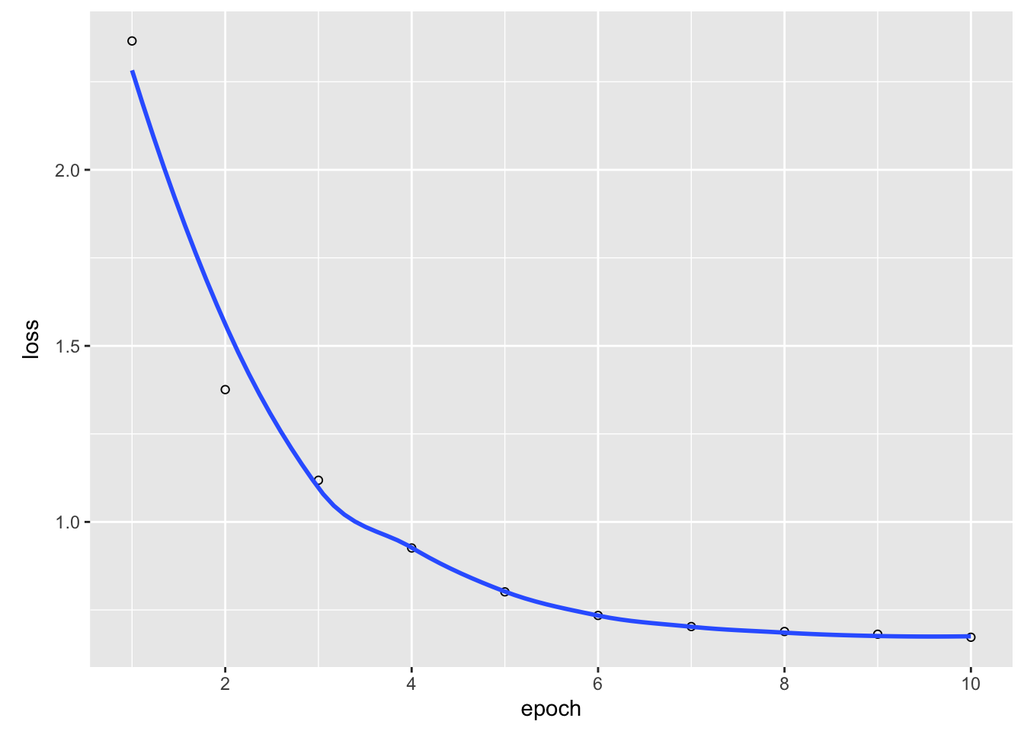

```r
history <- model |>
  fit(
    list(training_ratings$userId, training_ratings$movieId),
    training_ratings$rating,
    batch_size = 64,
    epochs = 10,
    verbose = 0
  )
plot(history)
```

and evaluate on the test set:

```r
model |> evaluate(list(test_ratings$userId, test_ratings$movieId),
  test_ratings$rating,
  verbose = 2
)
```

```
3152/3152 - 1s - 257us/step - loss: 0.6272
```

```
$loss
[1] 0.6272407
```

## Exercises

There are a few places in the notebook where an exercise is indicated. Specifically: